# 303.1. Galaxy photometry

For the Rubin Science Platform at data.lsst.cloud.  
Data Release: [Data Preview 1](https://dp1.lsst.io/)  
Container Size: large  
LSST Science Pipelines version: r29.2.0  
Last verified to run: 2025-09-02  
Repository: github.com/lsst/tutorial-notebooks

**Learning objective:** Explore the available measurements of galaxy photometry produced by the LSST pipelines and their applications.

**LSST data products:** `Object` table

**Packages:** `lsst.rsp.get_tap_service`

**Credit:** This notebook benefitted from an earlier exploration of simulated data and notebook development by Melissa Graham and Dan Taranu, helpful discussions with Jim Bosch, and ideas from Douglas Tucker.

**Get Support:** Everyone is encouraged to ask questions or raise issues in the [Support Category](https://community.lsst.org/c/support) of the Rubin Community Forum. Rubin staff will respond to all questions posted there.

## 1. Introduction

Photometry is the measurement of how much light is apparent from astronomical sources. The amount of light arriving on the telescope from the object is typically referred to as the flux density, or apparent magnitude (depending on units). Flux density is defined as the amount of energy arriving on the telescope per unit area, per unit time, per unit frequency (or wavelength) of the light.

The LSST Science Pipelines makes a variety of photometric measurements for point-like and extended sources. This notebook will teach the user about the automated photometry measurements for extended sources that are measured on the deepCoadd images and appear in the Object Catalog as part of the LSST pipelines data products.

The photometry measurements in the catalogs are flux densities in units of nano-Jansky [nJy]. 1 Jy = 10^{-23} ergs/s/cm^2/Hz.

### 1.1. Import packages

Import `numpy`, a fundamental package for scientific computing with arrays in Python (numpy.org), and `matplotlib`, a comprehensive library for data visualization ([matplotlib.org](https://matplotlib.org/); [matplotlib gallery](https://matplotlib.org/stable/gallery/index.html)).

From the `lsst` package, import modules for accessing the Table Access Protocol (TAP) service, the butler, and image display functions from the LSST Science Pipelines ([pipelines.lsst.io](https://pipelines.lsst.io/)).

```python
import numpy as np
import matplotlib.pyplot as plt

from lsst.rsp import get_tap_service

from scipy.stats import binned_statistic
```

### 1.2. Define parameters and functions

Get an instance of the TAP service, and assert that it exists.

```python
service = get_tap_service("tap")
assert service is not None
```

## 2. Types of photometry

This section will explore photometry measurements produced by the LSST pipelines, and provide some guidance for which are optimal for various applications for science with galaxies.

### 2.1. Explore the schema

Numerous photometry measurements are produced by the LSST Pipelines. Two types of photometry are in the object table. The first are total fluxes (see Section 3), which aim to approximate (or model) all of the light coming from object. The second class of fluxes are measured inside an on-sky aperture but not corrected for flux that may fall outside: thus they are apparent fluxes but do not recover the intrisic (total) flux (see Section 4 and 5). The apparent fluxes are optimized for other purposes, such as for measuring accurate light profiles or accurate colors.

Schema for the object catalog for DP1 [is available here](https://sdm-schemas.lsst.io/). It lists the catalog header and brief explanation of the parameters.

First, see what is available in the object table by querying the `tap_schema` columns, and printing all the parameters available related to "Flux" measured in the i-band (as an example). For clarity, the return also omits errors and flags associated with the photometric measurements outlined in section 1.1.

```python
query = "SELECT column_name, datatype, description, unit " \
        "FROM tap_schema.columns " \
        "WHERE table_name = 'dp1.Object'"

results = service.search(query).to_table()
```

```python
search_string = 'Flux'
band = 'i_'
exclude1 = 'Err'
exclude2 = 'flag'
for cname in results['column_name']:
    if cname.find(search_string) > -1 and cname.find(band) > -1 and \
       cname.find(exclude1) == -1 and cname.find(exclude2) == -1:

        print(cname)
```

```
i_ap03Flux
i_ap06Flux
i_ap09Flux
i_ap12Flux
i_ap17Flux
i_ap25Flux
i_ap35Flux
i_ap50Flux
i_ap70Flux
i_bdFluxB
i_bdFluxD
i_calibFlux
i_cModelFlux
i_cModelFlux_inner
i_deblend_zeroFlux
i_free_cModelFlux
i_free_cModelFlux_inner
i_free_psfFlux
i_gaap0p7Flux
i_gaap1p0Flux
i_gaap1p5Flux
i_gaap2p5Flux
i_gaap3p0Flux
i_gaapOptimalFlux
i_gaapPsfFlux
i_kronFlux
i_psfFlux
i_psfFlux_area
i_sersicFlux
```

The object catalog also has pre-computed AB magnitudes (`Mag` columns) for cModel and PSF. Query the `tap_schema` columns, and print all the parameters available related to `Mag` measured in the i-band.

```python
search_string = 'Mag'
band = 'i_'
exclude1 = 'Err'
for cname in results['column_name']:
    if cname.find(search_string) > -1 and cname.find(band) > -1 and \
       cname.find(exclude1) == -1:

        print(cname)
```

```
i_cModelMag
i_psfMag
```

### 2.2. Select a galaxy sample

Below, query the DP1 `objectTable` for a selection of photometric measurements.

Limit the search to contain galaxies using the `i_extendedness` flag (which will exclude point sources). Further, identify objects which have been detected at high signal to noise > 20 and whose photometric measurements have not been flagged as having an issue (`i_kronFlux_flag` or `i_cModel_flag` or `sersic_no_data_flag` = 0 means the photometry is ok). Also exclude very bright galaxies (i-band magnitude < 20).

Search for the sample using the DP1 imaging obtained in the Extended Chandra Deep Field South (ECDFS; center ra, dec = 53.2, -28.1 in degrees) which was one of the deepest imaging obtained as part of DP1.

```python
target_ra = 53.2
target_dec = -28.1
```

```python
query = "SELECT obj.objectId, obj.coord_ra, obj.coord_dec, " + \
        "obj.detect_fromBlend, obj.detect_isIsolated, " + \
        "obj.i_blendedness, obj.i_extendedness, " + \
        "obj.i_kronFlux, obj.i_kronFluxErr, obj.i_kronRad, " + \
        "obj.i_cModelFlux, obj.i_cModelFluxErr, obj.i_gaap1p0Flux, " + \
        "obj.g_gaap1p0Flux, obj.g_gaap3p0Flux, obj.sersic_index, " + \
        "obj.i_sersicFlux, obj.i_bdFluxB, obj.i_bdFluxD, " + \
        "obj.i_kronFlux_flag, obj.i_cModel_flag, obj.sersic_no_data_flag, " + \
        "obj.shape_xx, obj.shape_xy, obj.shape_yy, " + \
        "obj.i_ap03Flux, obj.i_ap06Flux, obj.i_ap09Flux, obj.i_ap12Flux, " + \
        "obj.i_ap17Flux, obj.i_ap25Flux, obj.i_ap35Flux, obj.i_ap50Flux " + \
        "FROM dp1.Object AS obj " + \
        "WHERE (obj.i_cModelFlux/obj.i_cModelFluxErr > 20) AND " + \
        "(obj.i_extendedness = 1) AND (obj.sersic_no_data_flag = 0) AND " + \
        "(obj.i_kronFlux_flag = 0) AND (obj.i_cModel_flag = 0) AND " + \
        "(scisql_nanojanskyToAbMag(obj.i_cModelFlux) > 20) AND " + \
        "CONTAINS(POINT('ICRS', obj.coord_ra, obj.coord_dec), " + \
        "CIRCLE('ICRS',"+str(target_ra)+","+str(target_dec)+", 0.1)) = 1 "
```

```python
job = service.submit_job(query)
job.run()
job.wait(phases=['COMPLETED', 'ERROR'])
print('Job phase is', job.phase)
```

```
Job phase is COMPLETED
```

```python
if job.phase == 'ERROR':
    job.raise_if_error()
assert job.phase == 'COMPLETED'
```

Print the results of the search query.

```python
results = job.fetch_result()
tab = results.to_table()
tab
```

*Table length=3415*

| objectId int64 | coord_ra deg float64 | coord_dec deg float64 | detect_fromBlend bool | detect_isIsolated bool | i_blendedness float32 | i_extendedness float32 | i_kronFlux nJy float32 | i_kronFluxErr nJy float32 | i_kronRad float32 | i_cModelFlux nJy float32 | i_cModelFluxErr nJy float32 | i_gaap1p0Flux nJy float32 | g_gaap1p0Flux nJy float32 | g_gaap3p0Flux nJy float32 | sersic_index float32 | i_sersicFlux nJy float32 | i_bdFluxB nJy float32 | i_bdFluxD nJy float32 | i_kronFlux_flag bool | i_cModel_flag bool | sersic_no_data_flag bool | shape_xx pix2 float32 | shape_xy pix2 float32 | shape_yy pix2 float32 | i_ap03Flux nJy float32 | i_ap06Flux nJy float32 | i_ap09Flux nJy float32 | i_ap12Flux nJy float32 | i_ap17Flux nJy float32 | … |
| --- | --- | --- | --- | --- | --- | --- | --- | --- | --- | --- | --- | --- | --- | --- | --- | --- | --- | --- | --- | --- | --- | --- | --- | --- | --- | --- | --- | --- | --- | --- |
| 611254385447544670 | 53.196927847186444 | -28.1804600718091 | True | False | 2.55524e-05 | 1.0 | 6018.85 | 57.2624 | 5.28506 | 6624.39 | 36.3065 | 4359.9 | 375.164 | 645.085 | 1.82671 | 6117.17 | 7542.89 | 5583.97 | False | False | False | 9.04622 | 0.613085 | 13.5986 | 1813.42 | 3933.53 | 5041.48 | 5571.84 | 5888.74 | … |
| 611254385447544671 | 53.19726601065951 | -28.1822341580892 | True | False | 0.00778949 | 1.0 | 843.99 | 64.7884 | 6.00986 | 955.275 | 41.2438 | 546.298 | 313.86 | 450.621 | 4.0311 | 790.634 | 988.255 | 766.448 | False | False | False | 9.8238 | 0.496949 | 19.5712 | 220.921 | 484.32 | 647.856 | 762.393 | 840.881 | … |
| 611254385447544672 | 53.198798287317125 | -28.179788251097747 | True | False | 0.0051192 | 1.0 | 589.539 | 54.5148 | 5.04057 | 522.132 | 25.9248 | 463.538 | 332.443 | 480.736 | 1.91497 | 580.486 | 606.066 | 522.872 | False | False | False | 8.34709 | 0.838076 | 9.25815 | 206.376 | 423.048 | 503.375 | 557.332 | 568.097 | … |
| 611254385447544688 | 53.1334069598854 | -28.18051608260111 | True | False | 0.0547919 | 1.0 | 1959.29 | 43.7322 | 4.156 | 1869.68 | 23.1372 | 1728.79 | 1424.43 | 1705.37 | 4.4447 | 1927.4 | 1958.49 | 1838.16 | False | False | False | 6.57617 | -1.46361 | 6.40932 | 862.233 | 1561.37 | 1808.45 | 1923.02 | 1994.92 | … |
| 611254385447544708 | 53.13791468796697 | -28.16274697875353 | True | False | 0.00952725 | 1.0 | 874.149 | 39.5331 | 3.84487 | 796.676 | 19.5714 | 809.129 | 353.69 | 515.152 | 5.66921 | 846.656 | 798.454 | 799.426 | False | False | False | 4.31486 | 0.193086 | 5.2599 | 438.852 | 716.456 | 828.858 | 888.12 | 1012.76 | … |
| 611254385447544709 | 53.132257927134766 | -28.16659920666505 | True | False | 0.00643329 | 1.0 | 3546.08 | 119.228 | 11.5203 | 4084.18 | 72.3724 | 1296.43 | 465.274 | 1105.05 | 3.85711 | 6783.63 | 4579.83 | 2531.25 | False | False | False | 26.7702 | -3.23608 | 21.9209 | 440.929 | 1119.83 | 1678.8 | 2061.74 | 2613.9 | … |
| 611254385447544710 | 53.14235306936339 | -28.164458551572867 | True | False | 0.000453248 | 1.0 | 1345.03 | 55.7257 | 5.32483 | 1425.89 | 32.4023 | 1014.32 | 383.904 | 543.342 | 0.905101 | 1294.57 | 1750.83 | 1301.34 | False | False | False | 10.2958 | -0.73507 | 12.8173 | 406.784 | 924.919 | 1180.77 | 1285.19 | 1277.56 | … |
| 611254385447544711 | 53.14249653587028 | -28.176201285069098 | True | False | 0.00066845 | 1.0 | 1144.07 | 60.2769 | 5.631 | 1032.82 | 27.548 | 837.146 | 637.767 | 855.186 | 4.53282 | 1118.85 | 1031.01 | 899.098 | False | False | False | 8.94127 | -0.0640278 | 6.27459 | 392.18 | 732.72 | 933.6 | 1068.94 | 1202.1 | … |
| 611254385447544687 | 53.13851073674786 | -28.167620876533874 | True | False | 0.00669168 | 1.0 | 2318.04 | 42.262 | 4.08279 | 2128.36 | 20.3774 | 2121.73 | 1330.87 | 1517.57 | 5.99998 | 2157.22 | 2124.57 | 2105.51 | False | False | False | 5.04899 | -0.295263 | 5.04941 | 1122.2 | 1880.03 | 2155.67 | 2331.62 | 2443.33 | … |
| 611254385447544712 | 53.12184924256594 | -28.168119072755374 | True | False | 0.0133237 | 1.0 | 1052.17 | 48.0556 | 4.61556 | 1113.29 | 29.5018 | 833.606 | 462.538 | 661.158 | 2.90778 | 1130.07 | 1110.47 | 961.537 | False | False | False | 6.1884 | 1.21349 | 11.7068 | 369.817 | 746.588 | 949.289 | 1017.8 | 1040.67 | … |
| 611254385447544713 | 53.13789671815362 | -28.175109249407495 | True | False | 0.0367149 | 1.0 | 1040.21 | 53.2293 | 5.00992 | 889.168 | 22.5484 | 845.635 | 387.116 | 722.322 | 5.86556 | 1202.08 | 891.633 | 852.633 | False | False | False | 6.40817 | -0.0757515 | 5.25277 | 427.324 | 744.595 | 890.127 | 990.736 | 1152.57 | … |
| 611254385447544704 | 53.13999427109625 | -28.167077826115072 | True | False | 0.000843636 | 1.0 | 1338.66 | 49.5786 | 4.76992 | 1284.18 | 26.2861 | 1089.8 | 532.204 | 729.233 | 0.570971 | 1221.98 | 1542.38 | 1288.24 | False | False | False | 9.23703 | -3.67454 | 10.5158 | 471.895 | 986.739 | 1231.24 | 1299.26 | 1346.09 | … |
| 611254385447544696 | 53.139668081861565 | -28.171158166398737 | True | False | 0.00188084 | 1.0 | 1576.75 | 58.0149 | 5.5163 | 1268.66 | 23.213 | 1180.91 | 1163.01 | 1692.87 | 5.99098 | 1717.33 | 1309.15 | 1226.87 | False | False | False | 6.80839 | -0.130121 | 6.16629 | 572.288 | 1047.53 | 1253.07 | 1412.19 | 1672.09 | … |
| 611254385447544706 | 53.12580444979522 | -28.1742883581862 | True | False | 0.000554989 | 1.0 | 1154.85 | 48.532 | 4.63082 | 902.834 | 20.7191 | 904.344 | 366.086 | 498.37 | 5.99157 | 1017.44 | 900.443 | 882.628 | False | False | False | 5.10729 | -0.101972 | 5.45125 | 463.048 | 785.265 | 946.576 | 1101.62 | 1171.76 | … |
| 611254385447544693 | 53.139233135213125 | -28.177719256631434 | True | False | 0.00370562 | 1.0 | 1914.2 | 59.2467 | 5.56042 | 1633.13 | 27.1873 | 1374.52 | 979.827 | 1357.47 | 3.11831 | 1926.45 | 1931.49 | 1588.68 | False | False | False | 9.30701 | -0.674206 | 8.67378 | 603.71 | 1231.31 | 1520.79 | 1728.39 | 1954.01 | … |
| 611254385447544707 | 53.131244812016796 | -28.164301864562006 | True | False | 0.000767627 | 1.0 | 938.669 | 44.2952 | 4.25192 | 834.55 | 19.8887 | 844.945 | 387.017 | 597.606 | 6.0 | 843.658 | 844.08 | 837.259 | False | False | False | 5.22281 | -0.0119719 | 5.00656 | 452.511 | 745.248 | 853.641 | 920.003 | 1114.46 | … |
| 611254385447544692 | 53.13324544722604 | -28.165936615043606 | True | False | 0.00390644 | 1.0 | 1668.51 | 49.0513 | 4.76948 | 1630.71 | 25.7117 | 1380.11 | 462.867 | 636.339 | 0.773023 | 1617.02 | 1944.45 | 1635.43 | False | False | False | 7.31123 | 2.32475 | 11.4547 | 605.147 | 1278.95 | 1513.34 | 1598.41 | 1692.75 | … |
| 611254385447544729 | 53.13537390662842 | -28.168412634376303 | True | False | 0.430555 | 1.0 | 9474.5 | 328.975 | 28.0712 | 2734.32 | 87.6303 | 630.309 | 305.484 | 750.092 | 3.36841 | 3748.96 | 2729.27 | 2042.26 | False | False | False | 40.1179 | 14.6703 | 132.91 | 279.832 | 533.367 | 721.491 | 955.97 | 1429.48 | … |
| ... | ... | ... | ... | ... | ... | ... | ... | ... | ... | ... | ... | ... | ... | ... | ... | ... | ... | ... | ... | ... | ... | ... | ... | ... | ... | ... | ... | ... | ... | … |
| 611255072642313257 | 53.17023418840526 | -28.00431090561822 | True | False | 0.0395665 | 1.0 | 855.899 | 53.4061 | 5.12536 | 840.003 | 23.6764 | 746.882 | 307.62 | 453.144 | 1.15507 | 840.808 | 933.329 | 834.535 | False | False | False | 9.34916 | 1.53112 | 5.47386 | 353.964 | 690.448 | 796.76 | 827.644 | 909.729 | … |
| 611255072642313157 | 53.191281071678034 | -28.013092552084622 | True | False | 0.000979161 | 1.0 | 464.602 | 31.6539 | 3.09638 | 441.947 | 21.0998 | 423.822 | 129.766 | 137.514 | 3.39422 | 506.374 | 475.459 | 443.646 | False | False | False | 7.24486 | 0.524554 | 5.08058 | 231.83 | 373.927 | 450.857 | 430.145 | 462.889 | … |
| 611255072642313158 | 53.19241903367821 | -28.01238675191122 | True | False | 0.000538889 | 1.0 | 1492.32 | 188.95 | 18.1726 | 594.93 | 26.4674 | 474.547 | 180.07 | 259.575 | 0.573534 | 611.483 | 681.856 | 596.586 | False | False | False | 10.3002 | -6.99878 | 12.9255 | 205.173 | 440.99 | 519.301 | 552.806 | 466.347 | … |
| 611255072642313223 | 53.20187752574822 | -28.011830707015303 | True | False | 0.00820966 | 1.0 | 5668.0 | 39.1137 | 3.65578 | 5512.78 | 22.1091 | 5325.73 | 1053.28 | 1175.81 | 1.03987 | 5461.56 | 5683.46 | 5526.56 | False | False | False | 6.33081 | 0.543492 | 4.81811 | 2811.95 | 4843.44 | 5415.42 | 5625.9 | 5747.62 | … |
| 611255072642313256 | 53.17306878479608 | -28.00641102134664 | True | False | 0.000237623 | 1.0 | 1189.84 | 54.3475 | 5.2178 | 1210.26 | 30.5575 | 900.381 | 452.193 | 656.808 | 0.760444 | 1173.04 | 1666.74 | 1213.78 | False | False | False | 11.1706 | -3.42166 | 15.1764 | 351.094 | 825.228 | 1085.33 | 1128.42 | 1148.3 | … |
| 611255072642313252 | 53.17027666797002 | -28.006166451694114 | True | False | 1.25513e-06 | 1.0 | 1942.03 | 32.4056 | 3.15589 | 1967.71 | 20.8909 | 1884.4 | 840.656 | 979.35 | 5.13896 | 1922.7 | 1965.5 | 1923.51 | False | False | False | 5.04716 | 0.325417 | 5.37331 | 1021.16 | 1713.54 | 1888.39 | 1942.88 | 1965.86 | … |
| 611255072642313250 | 53.172850375787114 | -28.00796616315619 | True | False | 7.52207e-05 | 1.0 | 5172.9 | 48.8043 | 4.73958 | 5083.71 | 28.1692 | 4011.36 | 1441.18 | 1937.62 | 0.524515 | 4926.79 | 6462.66 | 5098.54 | False | False | False | 8.03174 | 4.18749 | 15.4342 | 1688.61 | 3690.81 | 4601.79 | 4909.87 | 5137.82 | … |
| 611255072642313249 | 53.17116084639328 | -28.00421412937987 | True | False | 0.000784868 | 1.0 | 6727.95 | 47.3428 | 4.51595 | 6666.16 | 27.481 | 5564.65 | 1801.58 | 2152.63 | 0.654341 | 6504.57 | 8498.12 | 6684.79 | False | False | False | 9.28057 | 0.344461 | 9.75093 | 2428.48 | 5181.47 | 6195.84 | 6507.26 | 6685.01 | … |
| 611255072642313222 | 53.2013736966671 | -28.012418066332 | True | False | 0.00477363 | 1.0 | 7160.27 | 46.4819 | 4.32675 | 7248.86 | 26.8062 | 6061.9 | 833.774 | 996.112 | 3.76961 | 7199.04 | 7244.6 | 6494.71 | False | False | False | 7.20259 | 0.0453614 | 6.66745 | 2941.26 | 5485.32 | 6566.43 | 7000.7 | 7166.41 | … |
| 611255072642313174 | 53.176345104255134 | -28.01208398052733 | True | False | 0.0439997 | 1.0 | 1274.71 | 46.9674 | 4.53709 | 1218.94 | 24.9809 | 1068.31 | 623.626 | 805.914 | 0.773852 | 1277.08 | 1464.09 | 1222.42 | False | False | False | 7.62133 | 1.71155 | 9.61831 | 478.802 | 974.931 | 1183.24 | 1254.13 | 1319.79 | … |
| 611255072642313179 | 53.17702969866711 | -28.013220305310938 | True | False | 0.280033 | 1.0 | 594.368 | 47.51 | 4.61235 | 538.702 | 22.799 | 498.629 | 324.892 | 455.467 | 3.88928 | 567.579 | 621.557 | 550.911 | False | False | False | 9.1675 | -0.991261 | 6.98671 | 237.062 | 452.574 | 536.37 | 572.987 | 626.354 | … |
| 611255072642313178 | 53.17785604804501 | -28.01054338803276 | True | False | 0.0985817 | 1.0 | 420.831 | 47.5318 | 4.6012 | 449.065 | 22.2849 | 405.34 | 308.068 | 462.358 | 3.35672 | 430.544 | 471.577 | 450.313 | False | False | False | 6.82411 | 0.780469 | 6.17998 | 207.681 | 396.776 | 381.878 | 414.342 | 481.54 | … |
| 611255072642313177 | 53.17807141534588 | -28.010953967067866 | True | False | 0.0434244 | 1.0 | 548.186 | 41.6479 | 4.0583 | 526.718 | 20.1524 | 518.214 | 173.596 | 339.787 | 5.57485 | 558.344 | 525.851 | 516.863 | False | False | False | 5.2266 | -0.390099 | 5.00447 | 277.818 | 467.838 | 523.914 | 554.811 | 634.127 | … |
| 611255072642313176 | 53.17591639246409 | -28.013775425567584 | True | False | 0.000591536 | 1.0 | 1110.48 | 51.9062 | 5.02765 | 1065.91 | 26.2604 | 887.463 | 720.07 | 970.686 | 0.790164 | 1095.29 | 1330.1 | 1068.99 | False | False | False | 7.56738 | 0.807425 | 11.5429 | 387.831 | 816.641 | 990.156 | 1062.66 | 1131.77 | … |
| 611255072642313175 | 53.17934177956848 | -28.011312845208455 | True | False | 0.00996476 | 1.0 | 764.845 | 37.2241 | 3.65143 | 765.196 | 20.0028 | 737.402 | 255.231 | 388.286 | 5.44329 | 761.611 | 770.757 | 767.385 | False | False | False | 5.20637 | 0.219013 | 4.94947 | 414.111 | 668.644 | 729.545 | 771.829 | 860.665 | … |
| 611255072642313172 | 53.176618094491474 | -28.01272211276504 | True | False | 0.0164287 | 1.0 | 2720.88 | 35.246 | 3.43515 | 2674.23 | 20.5701 | 2592.6 | 745.412 | 870.112 | 3.97655 | 2687.18 | 2725.59 | 2673.67 | False | False | False | 5.1012 | -0.328203 | 5.49309 | 1401.21 | 2352.43 | 2626.45 | 2673.29 | 2705.44 | … |
| 611255072642313171 | 53.1776827869903 | -28.012784590849083 | True | False | 0.00510771 | 1.0 | 8631.77 | 55.5416 | 5.38972 | 8129.56 | 29.7255 | 6105.33 | 1502.91 | 2222.0 | 0.82965 | 8258.68 | 10804.7 | 8152.94 | False | False | False | 20.8762 | -1.31625 | 6.09615 | 2466.93 | 5560.64 | 7157.49 | 7988.4 | 8593.74 | … |
| 611255072642313165 | 53.22247074477941 | -28.01132744515098 | True | False | 7.49282e-08 | 1.0 | 3565.86 | 48.7109 | 4.52078 | 3535.11 | 26.4576 | 2983.18 | 1526.1 | 1818.8 | 4.36035 | 3488.68 | 3533.92 | 3179.08 | False | False | False | 7.99947 | 0.2084 | 5.83063 | 1436.43 | 2688.48 | 3238.73 | 3460.6 | 3597.95 | … |
| 611255072642313207 | 53.15719031397691 | -28.01120444790971 | True | False | 0.00206837 | 1.0 | 591.463 | 43.6672 | 4.18805 | 557.342 | 25.9141 | 481.11 | 228.279 | 362.25 | 2.90524 | 647.188 | 651.724 | 558.571 | False | False | False | 10.0677 | -1.71456 | 7.98101 | 217.43 | 445.904 | 527.788 | 589.399 | 504.982 | … |

Below, convert the fluxes (units $nJy$) extracted from the `objectTable` into AB magnitudes using: $m_{AB} = -2.5log( f_{nJy}) + 31.4$ (see e.g. [AB Magnitudes Wikipedia page](https://en.wikipedia.org/wiki/AB_magnitude) for the conversion between flux in Jy and AB magnitudes).

> **Warning:** The following cell will produce warnings for invalid value encountered in log10, which happens if the source flux is negative. This occasionally happens from aperture photometry if the included pixels inside the aperture have negative values and can be safely ignored for this example. The log10 will return a NaN which can be filtered out later.

```python
cmodel_mag = -2.50 * np.log10(tab['i_cModelFlux']) + 31.4
sersic_mag = -2.50 * np.log10(tab['i_sersicFlux']) + 31.4
bdFluxD_mag = -2.50 * np.log10(tab['i_bdFluxD']) + 31.4
bdFluxB_mag = -2.50 * np.log10(tab['i_bdFluxB']) + 31.4
ap06_mag = -2.50 * np.log10(tab['i_ap06Flux']) + 31.4
ap09_mag = -2.50 * np.log10(tab['i_ap09Flux']) + 31.4
ap17_mag = -2.50 * np.log10(tab['i_ap17Flux']) + 31.4
ap12_mag = -2.50 * np.log10(tab['i_ap12Flux']) + 31.4
ap35_mag = -2.50 * np.log10(tab['i_ap35Flux']) + 31.4
kron_mag = -2.50 * np.log10(tab['i_kronFlux']) + 31.4
gaap_mag = -2.50 * np.log10(tab['i_gaap1p0Flux']) + 31.4
```

```
/tmp/ipykernel_143067/3117612974.py:7: RuntimeWarning: invalid value encountered in log10
  ap17_mag = -2.50 * np.log10(tab['i_ap17Flux']) + 31.4
/tmp/ipykernel_143067/3117612974.py:9: RuntimeWarning: invalid value encountered in log10
  ap35_mag = -2.50 * np.log10(tab['i_ap35Flux']) + 31.4
/tmp/ipykernel_143067/3117612974.py:10: RuntimeWarning: invalid value encountered in log10
  kron_mag = -2.50 * np.log10(tab['i_kronFlux']) + 31.4
```

Below, store two shape parameters that will be useful for interpreting photometric apertures. First, the Kron Radius, which is a good proxy for the size of the galaxy light profile. Then, the sersic index, which describes the shape of the light profile of galaxies.

```python
i_kronRad = tab['i_kronRad']
sersic_index = tab['sersic_index']
```

## 3. Total fluxes

The following measurements are available: total fluxes from the sersic model (with shape parameters left free), from cModel (sum of bulge and disk sersic components fitted to the galaxy); and bulge/disk (BD) fluxes with sersic index fixed.

##### Sersic fluxes

This photometric measurement models all galaxies as a single Sersic profile and calculates its total flux according to the best fitting model. More information the sersic profile [is available here](https://en.wikipedia.org/wiki/S%C3%A9rsic_profile).

The best fit sersic model is evaluated based on a model to all filters, and then the flux in each filter is calculated by integrating the galaxy light from the best fit model, assuming the best-fit sersic shape parameters.

```
<f>_sersicFlux    : Flux from the final sersic fit. Forced on <f>-band.
<f>_sersicFluxErr : Uncertainty of <f>_sersicFlux
sersic_no_data_flag   : Failure flag for <f>_sersicFlux
```

DP1 is the first Rubin data release that contains Sersic fluxes. cModel fluxes (see below) have seen more testing and been in use longer (and originate with SDSS). The LSST pipeline package responsible for sersic fluxes is called `multiprofit` and documentation is [available here](https://pipelines.lsst.io/modules/lsst.multiprofit/index.html#module-lsst.multiprofit).

##### Bulge/Disk (BD) fluxes

This is a photometric measurement similar to using a single Sersic profile, integrated to estimate the flux. But, rather than using the best fit sersic index obtained from modeling the 6 images in each filter, the BD fluxes fixes the sersic index n to either 1 (exponential disk) or 4 (de Vaucouleurs bulge).

```
<f>_bdFlux*    : Flux from the final sersic fit. Forced on <f>-band. If * = D then this refers to disk and assumes sersic index n=1 (exponential profile). * = B refers to a bulge with de Vaucouleurs profile (n=4).
<f>_bdFlux*Err : Uncertainty of <f>_sersicFlux
```

##### Composite Model (CModel) fluxes

Similar in nature to those measured for SDSS (information [available here](https://www.sdss3.org/dr8/algorithms/magnitudes.php#cmodel)) that will be familiar to SDSS users. In short, it is the linear combination of the best fit exponential (disk or D; sersic index n = 1) and de Vaucouleurs (bulge or B; sersic index n = 4) profiles. Thus, cModel is a good compromise between the BD fluxes that assume either a bulge or a disk.

```
<f>_cModelFlux    : Flux from the final cmodel fit. Forced on <f>-band.
<f>_cModelFluxErr : Uncertainty of <f>_cModelFlux
<f>_cModel_flag   : Failure flag for <f>_cModelFlux
```

For most cases the "fixed" cModel photometry (i.e. the catalog entries listed above) are preferred to that measured with more degrees of freedom labeled `<f>_free_cModelFlux`. The difference is that the fixed ones above uses a reference band (recorded as `refBand` in the schema) where the galaxy is well detected to determine the other parameters, which are then fixed when fitting for the flux in the other bands. The `_free_cModelFlux` measurement allows all parameters to be free and independent in each filter. The fixed `_cModelFlux` measurements are generally recommended for galaxy science applications where total flux measurements are needed (e.g. for intrinsic luminosity or mass).

In the `Object` table, a pre-computed AB magnitude (`<f>_cModelMag`) also exists for this measurement.

### 3.1. Comparing total fluxes

This section will make several plots that shows how the different photometric measurements compare.

First, compare `cModelFlux` (two component bulge+disk sersic model flux) to `sersicFlux` (single sersic model flux with shape parameters free), `bdFluxB` (sersic with n=4) and `bdFluxD` (sersic with n=1).

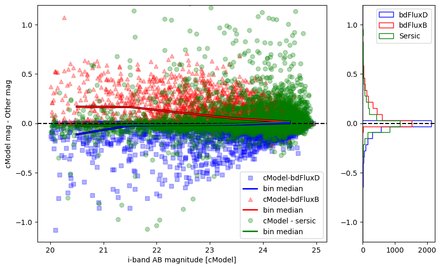

```python
fig, (ax, ax2) = plt.subplots(ncols=2, nrows=1,
                              width_ratios=[0.8, 0.2], figsize=(10, 6))

bins = np.arange(16, 27, 1)

ylims = [-1.2, 1.2]

ax.plot(cmodel_mag, (cmodel_mag-bdFluxD_mag), 's', alpha=.3,
        label='cModel-bdFluxD', color='blue')
x = cmodel_mag
y = (cmodel_mag-bdFluxD_mag)
bin_mean, bin_edge, binnum = binned_statistic(x, y,
                                              statistic='median', bins=bins)
binctr = bin_edge[:-1] + (bin_edge[1:]-bin_edge[:-1])/2
ax.plot(binctr, bin_mean, color='k', lw=3, label=None, zorder=10)
ax.plot(binctr, bin_mean, color='blue', lw=2, label='bin median', zorder=11)

ax.plot(cmodel_mag, (cmodel_mag-bdFluxB_mag), '^', alpha=.3,
        label='cModel-bdFluxB', color='r')
x = cmodel_mag
y = (cmodel_mag-bdFluxB_mag)
bin_mean, bin_edge, binnum = binned_statistic(x, y,
                                              statistic='median', bins=bins)
binctr = bin_edge[:-1] + (bin_edge[1:]-bin_edge[:-1])/2
ax.plot(binctr, bin_mean, color='k', lw=3, label=None, zorder=10)
ax.plot(binctr, bin_mean, color='r', lw=2, label='bin median', zorder=11)


ax.plot(cmodel_mag, (cmodel_mag - sersic_mag), 'o', alpha=.3,
        label='cModel - sersic', color='g')

x = cmodel_mag
y = (cmodel_mag-sersic_mag)
bin_mean, bin_edge, binnum = binned_statistic(x, y,
                                              statistic='median', bins=bins)
binctr = bin_edge[:-1] + (bin_edge[1:]-bin_edge[:-1])/2
ax.plot(binctr, bin_mean, color='k', lw=3, label=None, zorder=10)
ax.plot(binctr, bin_mean, color='g', lw=2, label='bin median', zorder=11)

ax.axhline(0, linestyle='--')
ax.set_xlabel('cModel Magnitude')
ax.set_ylabel('cModel mag - other mag')
ax.set_ylim([-1, 1])
ax.legend()

ax2.hist((cmodel_mag-bdFluxD_mag), orientation="horizontal",
         bins=np.linspace(ylims[0], ylims[1], 40), align='mid',
         histtype="step", color='blue', stacked=True, fill=False, label='bdFluxD')
ax2.hist((cmodel_mag-bdFluxB_mag), orientation="horizontal",
         bins=np.linspace(ylims[0], ylims[1], 40), align='mid',
         histtype="step", color='r', stacked=True, fill=False, label='bdFluxB')
ax2.hist((cmodel_mag-sersic_mag), orientation="horizontal",
         bins=np.linspace(ylims[0], ylims[1], 40), align='mid',
         histtype="step", color='g', stacked=True, fill=False, label='Sersic')

ax2.set_ylim(ylims)
ax2.axhline(0, linestyle='--', color='k')
ax.axhline(0, linestyle='--', color='k')
ax.set_xlabel('i-band AB magnitude [cModel]')
ax.set_ylabel('cModel mag - Other mag')
ax.set_ylim(ylims)

ax.legend()
ax2.legend()
```

Below, explore how the BD fluxes compare to sersic fluxes as a function of the shape of the light profile, sersic index n.

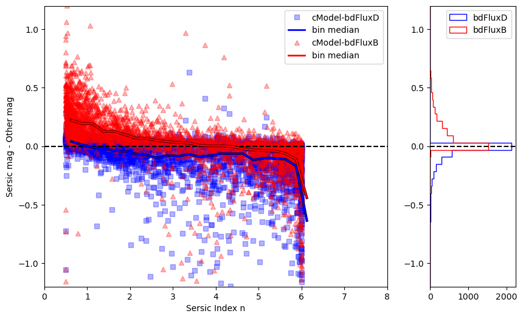

```python
fig, (ax, ax2) = plt.subplots(ncols=2, nrows=1,
                              width_ratios=[0.8, 0.2], figsize=(10, 6))

bins = np.arange(0, 7, 0.25)

ylims = [-1.2, 1.2]

ax.plot(sersic_index, (sersic_mag-bdFluxD_mag), 's', alpha=.3,
        label='cModel-bdFluxD', color='blue')
x = sersic_index
y = (sersic_mag-bdFluxD_mag)
bin_mean, bin_edge, binnum = binned_statistic(x, y,
                                              statistic='median', bins=bins)
binctr = bin_edge[:-1] + (bin_edge[1:]-bin_edge[:-1])/2
ax.plot(binctr, bin_mean, color='k', lw=3, label=None, zorder=10)
ax.plot(binctr, bin_mean, color='blue', lw=2, label='bin median', zorder=11)

ax.plot(sersic_index, (sersic_mag-bdFluxB_mag), '^', alpha=.3,
        label='cModel-bdFluxB', color='r')
x = sersic_index
y = (sersic_mag-bdFluxB_mag)
bin_mean, bin_edge, binnum = binned_statistic(x, y,
                                              statistic='median', bins=bins)
binctr = bin_edge[:-1] + (bin_edge[1:]-bin_edge[:-1])/2
ax.plot(binctr, bin_mean, color='k', lw=3, label=None, zorder=10)
ax.plot(binctr, bin_mean, color='r', lw=2, label='bin median', zorder=11)

ax.axhline(0, linestyle='--')

ax.set_ylabel('sersic mag - BD mag')
ax.set_ylim([-1, 1])
ax.legend()


ax2.hist((cmodel_mag-bdFluxD_mag), orientation="horizontal",
         bins=np.linspace(ylims[0], ylims[1], 40), align='mid',
         histtype="step", color='blue', stacked=True, fill=False, label='bdFluxD')
ax2.hist((cmodel_mag-bdFluxB_mag), orientation="horizontal",
         bins=np.linspace(ylims[0], ylims[1], 40), align='mid',
         histtype="step", color='r', stacked=True, fill=False, label='bdFluxB')

ax2.set_ylim(ylims)
ax2.axhline(0, linestyle='--', color='k')
ax.axhline(0, linestyle='--', color='k')
ax.set_xlabel('Sersic Index n')
ax.set_ylabel('Sersic mag - Other mag')
ax.set_ylim(ylims)
ax.set_xlim([0, 8])
ax.legend()
ax2.legend()
```

> Fig 2: Comparison of the sersic mag (flux measured with sersic parameters left free) with the bdFlux that is measured with sersic index fixed to either n=1 (D) or n=4 (B) as a function of sersic index n. Fixing the sersic index can inject scatter in the flux relative to leaving it free, but the sersic flux converges on bdFluxD(B) for n=1 and n=4.

## 4. Apparent fluxes

Here, apparent fluxes refers to photometry that are not corrected for flux outside of the measurement aperture (i.e. not corrected to be a total flux). These measurements have their own applications but should not be used to measure mass or luminosity.

##### Kron fluxes

A decent summary of Kron fluxes [in the NED documentation](https://ned.ipac.caltech.edu/level5/March05/Graham/Graham2_6.html). The aperture used for the fluxes is 2.5 x R1 where R1 is the luminosity weighted radius (also called "first moment"; Kron et al. 1980).

```
<f>_kronFlux      : Flux from Kron Flux algorithm. Measured on <f>-band.
<f>_kronFluxErr   : Uncertainty of <f>_kronFlux.
<f>_kronFlux_flag : Failure flag for <f>_kronFlux.
```

The Kron radius, `<f>_kronRad`, is also available. In this case of LSST pipeline output, the Kron flux is not corrected for light that is emitted outside of the Kron aperture. While in many cases it will collect the majority of light, it will not be as accurate as the cModel for science cases requiring total flux.

##### Aperture fluxes

This contains the enclosed flux inside a given aperture (and not corrected to total fluxes using an aperture correction that accounts for the flux falling outside the aperture). Fixed aperture size refers to the aperture radius in pixels.

```
<f>_ap<pix>Flux     : Flux within <pix>-pixel aperture. Forced on <f>-band.
<f>_ap<pix>FluxErr  : Uncertainty of <f>_ap<pix>Flux.
<f>_ap<pix>FluxFlag : Failure flag for <f>_ap<pix>Flux.
```

The apertures are 3, 6, 9, 12, 17, 25, 35, 50, and 70 pixels. In the column name, apertures are `03`, `06`, `09`, `12`, and so on. While aperture fluxes are not corrected for the loss outside the aperture, if the aperture size is much larger than the galaxy size then it will approximate the total flux of the galaxy. The general application of these measurements are for measuring radial profiles (see Section 4 below).

### 4.1. Comparing total to apparent fluxes

This section will make several plots that compare the `cModel` flux (which we take as the fiducial total flux, as commonly used for SDSS) to some of the apparent flux measurements. Kron, and aperture photometry are all measures of light within a fixed aperture.

Generally, magnitudes measured using aperture photometry in the LSST pipeline are fainter than those measured from cModel, because the fixed circular aperture systematically underestimates the flux in the galaxy wings (and the lost flux increases as the intrinsic size of the galaxy increases, e.g. as traced by the Kron radius).

First, compare `cModel` to `Kron` which should typically enclose 90% of the light.

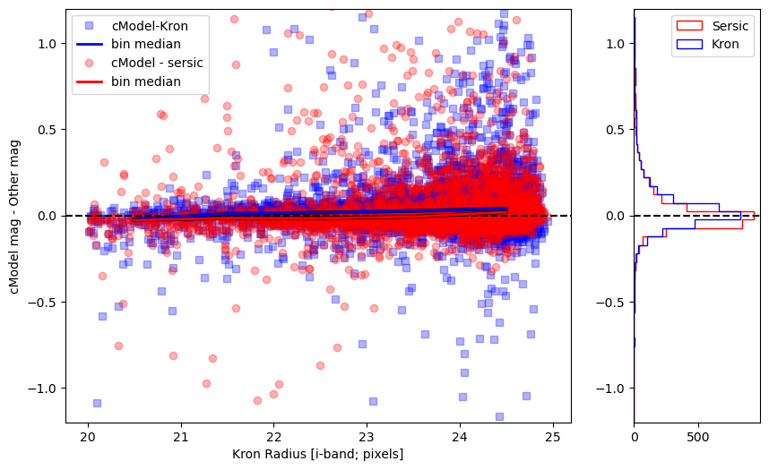

```python
fig, (ax, ax2) = plt.subplots(ncols=2, nrows=1,
                              width_ratios=[0.8, 0.2], figsize=(10, 6))

bins = np.arange(16, 27, 1)

ylims = [-1.2, 1.2]

ax.plot(cmodel_mag, (cmodel_mag - kron_mag), 's', alpha=.3,
        label='cModel-Kron', color='blue')
x = cmodel_mag
y = (cmodel_mag-kron_mag)
bin_mean, bin_edge, binnum = binned_statistic(x, y,
                                              statistic='median', bins=bins)
binctr = bin_edge[:-1] + (bin_edge[1:]-bin_edge[:-1]) / 2
ax.plot(binctr, bin_mean, color='k', lw=3, label=None, zorder=10)
ax.plot(binctr, bin_mean, color='blue', lw=2, label='bin median', zorder=11)

ax.plot(cmodel_mag, (cmodel_mag-sersic_mag), 'o', alpha=.3,
        label='cModel - sersic', color='r')

x = cmodel_mag
y = (cmodel_mag-sersic_mag)
bin_mean, bin_edge, binnum = binned_statistic(x, y,
                                              statistic='median', bins=bins)
binctr = bin_edge[:-1] + (bin_edge[1:]-bin_edge[:-1])/2
ax.plot(binctr, bin_mean, color='k', lw=3, label=None, zorder=10)
ax.plot(binctr, bin_mean, color='r', lw=2, label='bin median', zorder=11)

ax.axhline(0, linestyle='--')
ax.set_xlabel('cModel Magnitude')
ax.set_ylabel('cModel mag - sersic mag')
ax.set_ylim([-1, 1])
ax.legend()


ax2.hist((cmodel_mag-sersic_mag), orientation="horizontal",
         bins=np.linspace(ylims[0], ylims[1], 50), align='mid',
         histtype="step", color='red', stacked=True, fill=False, label='Sersic')
ax2.hist((cmodel_mag-kron_mag), orientation="horizontal",
         bins=np.linspace(ylims[0], ylims[1], 50), align='mid',
         histtype="step", color='blue', stacked=True, fill=False, label='Kron')

ax2.set_ylim(ylims)
ax2.axhline(0, linestyle='--', color='k')
ax.axhline(0, linestyle='--', color='k')
ax.set_xlabel('Kron Radius [i-band; pixels]')
ax.set_ylabel('cModel mag - Other mag')
ax.set_ylim(ylims)

ax.legend()
ax2.legend()
```

> Figure 3: A figure comparing the difference between cModel and Kron magnitudes, compared to the difference between cModel and sersic magnitudes (left panel). Generally, both Kron and sersic the measurements are in comparable agreement with cModel. The right panel shows the histogram of magnitude differences, demonstrating that there are not systematic offsets but slightly higher scatter from Kron with respect to cModel.

Below, explore how circular aperture photometry compares to cModel. Generally, magnitudes measured using aperture photometry in the LSST pipeline are fainter than those measured from cModel, because the fixed circular aperture systematically underestimates the flux in the galaxy wings (and the lost flux increases as the intrinsic size of the galaxy increases, e.g. as traced by the Kron radius).

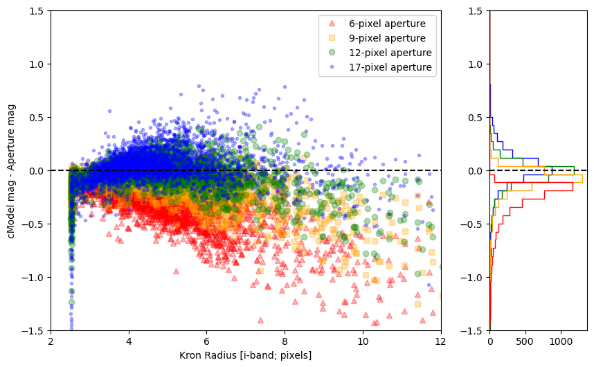

```python
fig, (ax, ax2) = plt.subplots(ncols=2, nrows=1,
                              width_ratios=[0.8, 0.2], figsize=(10, 6))

bins = np.arange(2, 15, 1)
ylims = [-1.5, 1.5]

ax.plot(i_kronRad, (cmodel_mag-ap06_mag), '^', alpha=.3,
        label='6-pixel aperture', color='red')
ax.plot(i_kronRad, (cmodel_mag-ap09_mag), 's', alpha=.3,
        label='9-pixel aperture', color='orange')
ax.plot(i_kronRad, (cmodel_mag-ap12_mag), 'o', alpha=.3,
        label='12-pixel aperture', color='green')
ax.plot(i_kronRad, (cmodel_mag-ap17_mag), '.', alpha=.3,
        label='17-pixel aperture', color='blue')

ax2.hist((cmodel_mag-ap17_mag), edgecolor='blue', orientation="horizontal",
         bins=np.linspace(ylims[0], ylims[1], 40), align='mid',
         histtype="step", stacked=True, fill=False)
ax2.hist((cmodel_mag-ap12_mag), edgecolor='green', orientation="horizontal",
         bins=np.linspace(ylims[0], ylims[1], 40), align='mid',
         histtype="step", stacked=True, fill=False)
ax2.hist((cmodel_mag-ap09_mag), edgecolor='orange', orientation="horizontal",
         bins=np.linspace(ylims[0], ylims[1], 40), align='mid',
         histtype="step", stacked=True, fill=False)
ax2.hist((cmodel_mag-ap06_mag), edgecolor='red', orientation="horizontal",
         bins=np.linspace(ylims[0], ylims[1], 40), align='mid',
         histtype="step", stacked=True, fill=False)

ax2.set_ylim(ylims)
ax.axhline(0, linestyle='--', color='k')
ax2.axhline(0, linestyle='--', color='k')
ax.set_xlabel('Kron Radius [i-band; pixels]')
ax.set_ylabel('cModel mag - Aperture mag')
ax.set_ylim(ylims)
ax.set_xlim([2, 12])
ax.legend()
```

> Figure 4: A comparison of the difference between cModel photometry and aperture photometry measured by the LSST pipelines for four different aperture sizes as a function of galaxy size (as measured using the Kron radius). The left panel shows the scatter plot of difference in photometry vs Kron radius, and the right panel shows a histogram of these values that demonstrate that larger aperture sizes have photometry that is closer to the cModel. The right panel shows histograms of the data in the left panel, where the colors indicate for the same data in each panel.

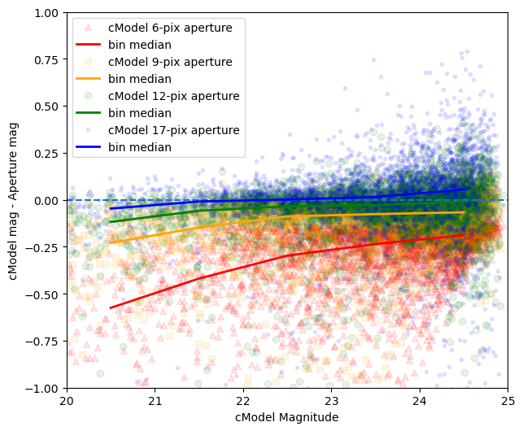

```python
fig, ax = plt.subplots(ncols=1, nrows=1, figsize=(7, 6))
ylims = [-1.2, 1.2]
bins = np.arange(16, 27, 1)

ax.plot(cmodel_mag, (cmodel_mag-ap06_mag), '^', alpha=.1,
        label='cModel 6-pix aperture', color='red')
x = cmodel_mag
y = (cmodel_mag-ap06_mag)
bin_mean, bin_edge, binnum = binned_statistic(x, y,
                                              statistic='median', bins=bins)
binctr = bin_edge[:-1] + (bin_edge[1:]-bin_edge[:-1])/2
ax.plot(binctr, bin_mean, color='red', lw=2, label='bin median', zorder=10)

ax.plot(cmodel_mag, (cmodel_mag-ap09_mag), 's', alpha=.1,
        label='cModel 9-pix aperture', color='orange')
x = cmodel_mag
y = (cmodel_mag-ap09_mag)
bin_mean, bin_edge, binnum = binned_statistic(x, y,
                                              statistic='median', bins=bins)
binctr = bin_edge[:-1] + (bin_edge[1:]-bin_edge[:-1])/2
ax.plot(binctr, bin_mean, color='orange', lw=2,
        label='bin median', zorder=10)

ax.plot(cmodel_mag, (cmodel_mag-ap12_mag), 'o', alpha=.1,
        label='cModel 12-pix aperture', color='green')
x = cmodel_mag
y = (cmodel_mag-ap12_mag)
bin_mean, bin_edge, binnum = binned_statistic(x, y,
                                              statistic='median', bins=bins)
binctr = bin_edge[:-1] + (bin_edge[1:]-bin_edge[:-1])/2
ax.plot(binctr, bin_mean, color='green', lw=2,
        label='bin median', zorder=10)

ax.plot(cmodel_mag, (cmodel_mag-ap17_mag), '.', alpha=.1,
        label='cModel 17-pix aperture', color='blue')
x = cmodel_mag
y = (cmodel_mag-ap17_mag)
bin_mean, bin_edge, binnum = binned_statistic(x, y,
                                              statistic='median', bins=bins)
binctr = bin_edge[:-1] + (bin_edge[1:]-bin_edge[:-1])/2
ax.plot(binctr, bin_mean, color='blue', lw=2,
        label='bin median', zorder=10)

ax.axhline(0, linestyle='--')
ax.set_xlabel('cModel Magnitude')
ax.set_ylabel('cModel mag - Aperture mag')
ax.set_ylim([-1, 1])
ax.set_xlim([20, 25])
ax.legend()
```

> Figure 5: A similar comparison of the difference between cModel photometry and aperture photometry measured by the LSST pipelines for four different aperture sizes, this time as a function of cModel magnitude. Running median is included.

These two figures show that the aperture photometry typically under-estimates the flux relative to the total flux estimated using cModel. As expected, there is a general trend for larger apertures to get closer to the total flux from cModel for large galaxies (i.e. whose Kron Radius is larger). There is also a general trend for the aperture photometry to be less discrepant at fainter magnitudes, since faint galaxies tend to be small.

### 4.2. Application of aperture photometry: radial profile

A science application for the aperture photometry is easy visualization of the radial profile of galaxies. In the cell below, make this plot for both a large galaxy (first) and a smaller galaxy of similar brightness (second). The query looks for bright galaxies whose `cModel` magnitude ~ 20 ABmag. Dividing the aperture flux by the surface area of the aperture yields the surface brightness, which can be plotted as a function of radius from the center of the galaxy to compare radial light profiles.

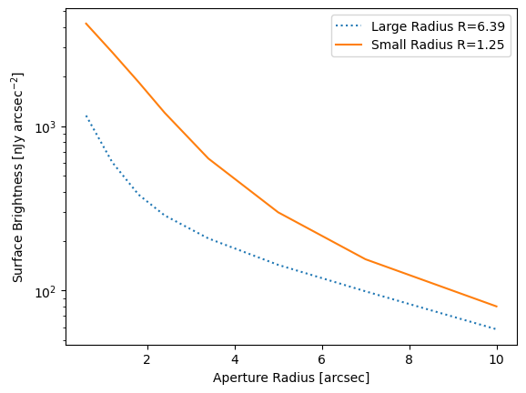

```python
wh = np.where((tab['i_kronRad'] > 20) & (cmodel_mag > 20)
              & (cmodel_mag < 20.5))[0]

indx = 0
arcsec_per_pix = 0.2

rad = np.array([3, 6, 9, 12, 17, 25, 35, 50]) * arcsec_per_pix
area = np.pi * rad**2
profile = np.array([tab['i_ap03Flux'][wh][indx], tab['i_ap06Flux'][wh][indx],
                    tab['i_ap09Flux'][wh][indx], tab['i_ap12Flux'][wh][indx],
                    tab['i_ap17Flux'][wh][indx], tab['i_ap25Flux'][wh][indx],
                    tab['i_ap35Flux'][wh][indx],
                    tab['i_ap50Flux'][wh][indx]]) / area

plt.plot(rad, profile, linestyle=':',
         label='Large Radius R='
         + str(np.round(i_kronRad[wh][indx]*arcsec_per_pix, 2)))
plt.xlabel('Aperture Radius [arcsec]')
plt.ylabel(r'Surface Brightness [nJy arcsec$^{-2}$]')

wh2 = np.where((tab['i_kronRad'] < 8) & (tab['i_kronRad'] > 5)
               & (cmodel_mag > 20) & (cmodel_mag < 20.5))[0]

indx = 0

profile = np.array([tab['i_ap03Flux'][wh2][indx], tab['i_ap06Flux'][wh2][indx],
                    tab['i_ap09Flux'][wh2][indx], tab['i_ap12Flux'][wh2][indx],
                    tab['i_ap17Flux'][wh2][indx], tab['i_ap25Flux'][wh2][indx],
                    tab['i_ap35Flux'][wh2][indx],
                    tab['i_ap50Flux'][wh2][indx]])/area

plt.plot(rad, profile,
         label='Small Radius R='
         + str(round(i_kronRad[wh2][indx]*arcsec_per_pix, 2)))
plt.legend()
plt.yscale('log')
```

## 5. Photometry for color

This section will explore GaaP fluxes (which are optimized for measuring accurate colors between bands).

##### GaaP fluxes

These are the Gaussian-aperture-and-PSF flux that is defined in [Kuijken et al. 2008](https://ui.adsabs.harvard.edu/abs/2008A%26A...482.1053K/abstract). The main goal of this method is to measure accurate colors while accounting for the different spatial resolution between filters. This is sometimes achieved in other datasets by convolving all images to the largest PSF, but this process of PSF-matching is computationally very time consuming for large images, thus motivating GaaP as a faster alternative. It is not a measure of total flux in a filter. Several measurement apertures are available.

**Aperture**

```
<f>_gaap<ap>Flux    : GaaP flux with <ap> aperture after multiplying the seeing aperture. Forced on <f>-band.
<f>_gaap<ap>FluxErr : Uncertainty of <f>_gaap<ap>Flux.
```

For photometric redshifts, and other analysis where accurate colors are important, it is recommended to start with the GaaP fluxes with 1.0 aperture (optimal aperture was found to not perform as well, and should not be used). The largest aperture `gaap3p0` might work better for larger galaxies, but `gaap1p0` has better overall performance. Experiment yourself to see how it works for your science case.

#### 5.1. Kron and GaaP comparison

In the next cell, compare the cModel instead to the Kron and GaaP measures.

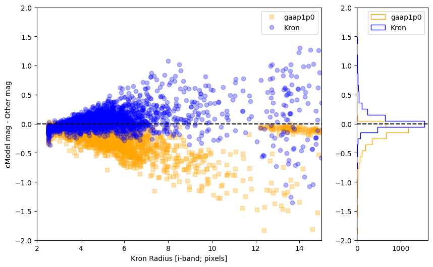

```python
fig, (ax, ax2) = plt.subplots(ncols=2, nrows=1,
                              width_ratios=[0.8, 0.2], figsize=(10, 6))
ylims = [-2, 2]

ax.plot(i_kronRad, (cmodel_mag-gaap_mag), 's', alpha=.3,
        label='gaap1p0', color='orange')

ax.plot(i_kronRad, (cmodel_mag-kron_mag), 'o', alpha=.3,
        label='Kron', color='blue')

ax2.hist((cmodel_mag-gaap_mag), orientation="horizontal",
         bins=np.linspace(ylims[0], ylims[1], 40), align='mid',
         histtype="step", color='orange', stacked=True, fill=False, label='gaap1p0')
ax2.hist((cmodel_mag-kron_mag), orientation="horizontal",
         bins=np.linspace(ylims[0], ylims[1], 40), align='mid',
         histtype="step", color='blue', stacked=True, fill=False, label='Kron')

ax2.set_ylim(ylims)
ax.axhline(0, linestyle='--', color='k')
ax2.axhline(0, linestyle='--', color='k')
ax.set_xlabel('Kron Radius [i-band; pixels]')
ax.set_ylabel('cModel mag - Other mag')
ax.set_ylim(ylims)
ax.set_xlim([2, 15])
ax.legend()
ax2.legend()
```

#### 5.2. CMD with GaaP

This section demonstrates using GaaP photometry to calculate accurate galaxy colors to identify different types of galaxies. First, define magnitudes from g, r, and i band photometry. The second cell will then compare the colors of galaxies that overlap the galaxy cluster with that in the field. In clusters, galaxies tend to be old, red elliptical galaxies and thus exhibit a well defined red sequence in color space.

The earlier query in Section 2 returned galaxies from a blank, "field" location (the ECDFS). These will be dominated by bluer star forming galaxies which are most common in field environments.

```python
cluster_ra = 37.83
cluster_dec = 6.98

query = "SELECT obj.objectId, obj.coord_ra, obj.coord_dec, " + \
        "obj.detect_fromBlend, obj.detect_isIsolated, " + \
        "obj.i_blendedness, obj.i_extendedness, " + \
        "obj.i_kronFlux, obj.i_kronFluxErr, obj.i_kronRad, " + \
        "obj.i_cModelFlux, obj.i_cModelFluxErr, obj.i_gaap1p0Flux,  obj.i_gaap3p0Flux, " + \
        "obj.g_gaap1p0Flux, obj.g_gaap3p0Flux, " + \
        "obj.i_kronFlux_flag, obj.i_cModel_flag " + \
        "FROM dp1.Object AS obj " + \
        "WHERE (obj.i_cModelFlux/obj.i_cModelFluxErr > 20) AND " + \
        "(obj.i_extendedness = 1) AND " + \
        "(obj.i_kronFlux_flag = 0) AND (obj.i_cModel_flag = 0) AND " + \
        "CONTAINS(POINT('ICRS', obj.coord_ra, obj.coord_dec), " + \
        "CIRCLE('ICRS',"+str(cluster_ra)+","+str(cluster_dec)+", 0.2)) = 1 "
```

```python
job = service.submit_job(query)
job.run()
job.wait(phases=['COMPLETED', 'ERROR'])
print('Job phase is', job.phase)
```

```
Job phase is COMPLETED
```

```python
if job.phase == 'ERROR':
    job.raise_if_error()
assert job.phase == 'COMPLETED'
```

```python
results = job.fetch_result()
tab2 = results.to_table()
```

First, calculate the magnitudes of galaxies in the 'field' location. Then, calculate the magnitudes for the other filters near the galaxy cluster from the query performed in the cell above. This will enable plotting their colors.

> **Warning:** Like in Section 2, the following cell will produce warnings for invalid value encountered in log10, which happens if the source flux is negative. This happens for a small number of objects and since the goal of the plot is to see the distribution of the majority of sources, the warning can be safely ignored.

```python
g_field_gaap_mag = -2.50 * np.log10(tab['g_gaap1p0Flux']) + 31.4
i_field_gaap_mag = -2.50 * np.log10(tab['i_gaap1p0Flux']) + 31.4
i_field_cmodel_mag = -2.50 * np.log10(tab['i_cModelFlux']) + 31.4
i_cluster_gaap_mag = -2.50 * np.log10(tab2['i_gaap1p0Flux']) + 31.4
g_cluster_gaap_mag = -2.50 * np.log10(tab2['g_gaap1p0Flux']) + 31.4
i_cluster_cmodel_mag = -2.50 * np.log10(tab2['i_cModelFlux']) + 31.4
```

```
/tmp/ipykernel_143067/3627765783.py:5: RuntimeWarning: invalid value encountered in log10
  g_cluster_gaap_mag = -2.50 * np.log10(tab2['g_gaap1p0Flux']) + 31.4
```

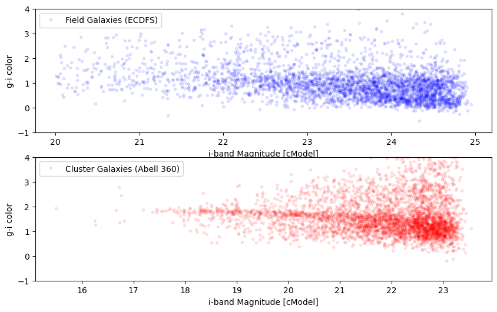

```python
fig, (ax, ax1) = plt.subplots(ncols=1, nrows=2, figsize=(10, 6))

ax.plot(i_field_cmodel_mag, (g_field_gaap_mag-i_field_gaap_mag),
        '.', alpha=.1, color='blue', label='Field Galaxies (ECDFS)')
ax.set_xlabel('i-band Magnitude [cModel]')
ax.set_ylabel('g-i color')
ax.set_ylim([-1, 4])
ax.legend()

ax1.plot(i_cluster_cmodel_mag, (g_cluster_gaap_mag-i_cluster_gaap_mag),
         '.', alpha=.1, color='r', label='Cluster Galaxies (Abell 360)')
ax1.set_xlabel('i-band Magnitude [cModel]')
ax1.set_ylabel('g-i color')
ax1.set_ylim([-1, 4])
ax1.legend()
```

> Figure 8: The g − i vs. i color-magnitude diagram for galaxies selected in the queries. Top panel shows the galaxies selected from in a random field that does not contain a galaxy cluster (ECDFS). The bottom panel shows galaxies from a field with a galaxy cluster (A360). The cluster galaxies appear as a "red sequence" with red i-g colors, because the Balmer / 4000 Angstrom break spectral feature that traces older stars sits between the bands.

A very nice red sequence appears from the red, old galaxies in the cluster!

## 6. Exercise for the learner

Compare the `<f>_free_cModelFlux` measurements to `<f>_cModelFlux` in the filters that are not the reference band where the `<f>_cModelFlux` was measured (i.e. `refBand`). Investigate how leaving the cModel measurements free differs from the one measured with parameters fixed to the `refBand`, as a function of decreasing signal to noise. As an additional exercise, check how the signal to noise in colors measured using `<f>_gaap1p0Flux` values compare to those measured with the larger 3.0" aperture, `<f>_gaap3p0Flux`, where the larger aperture may increase the noise.